# 散布図

## 散布図

`ggplot2`パッケージでは`ggplot2::geom_point`関数を用いることで散布図を描くことができます。

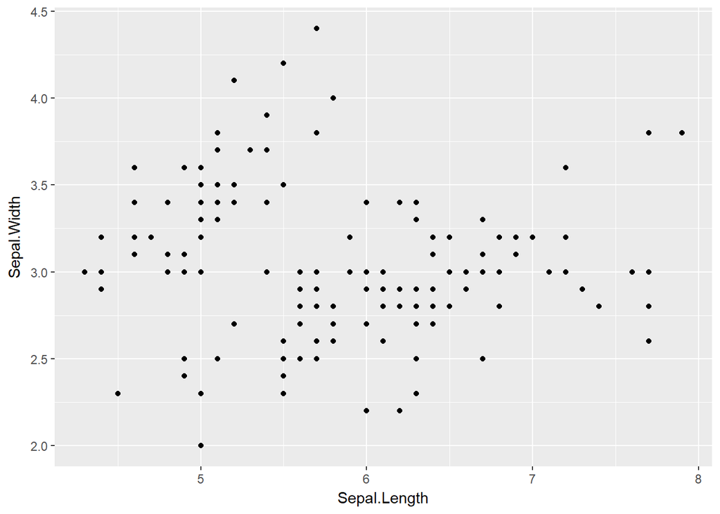

```r
iris %>%
  ggplot2::ggplot(ggplot2::aes(x = Sepal.Length, y = Sepal.Width)) +
    ggplot2::geom_point()
```

## 層別散布図

`car::scatterplot`関数は層別の散布図を描くことも可能です。ここでは分かりやすくするために回帰線などは描いていません。

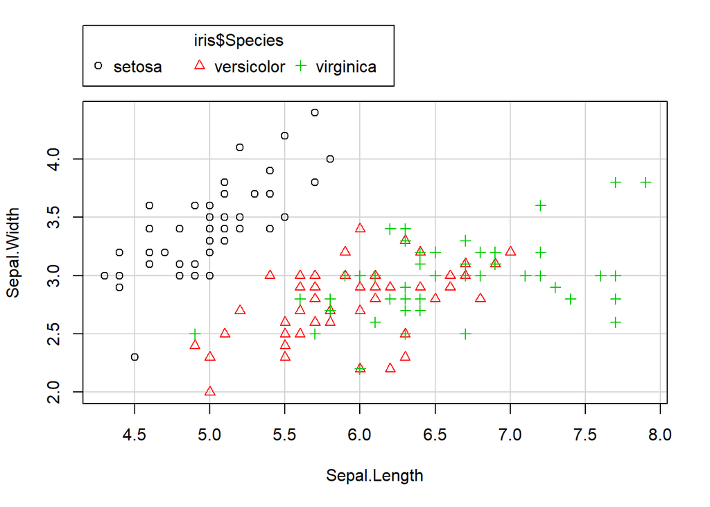

```r
car::scatterplot(Sepal.Width ~ Sepal.Length, data = iris, groups = iris$Species,
                 reg.line = FALSE, smooth = FALSE, spread = FALSE)
```

`ggplot2::geom_point`関数で層別表示を行うには`ggplot2::aes`関数を用いて色を変える場合は`colour`オプションを層別でマーカの形を変える場合は`shape`オプションを指定してください。

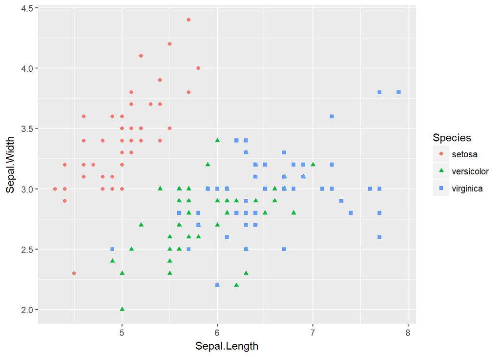

```r
iris %>%
  ggplot2::ggplot(ggplot2::aes(x = Sepal.Length, y = Sepal.Width)) +
    ggplot2::geom_point(ggplot2::aes(colour = Species, shape = Species))
```

## 散布図と回帰線

散布図は前述のように相関関係や回帰分析の際に利用されますので回帰線を描ける必要があります。

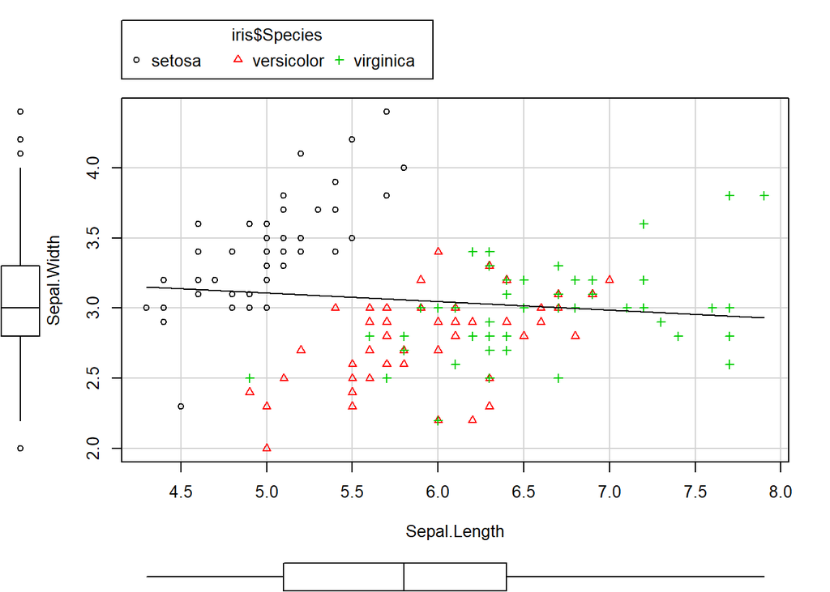

```r
car::scatterplot(Sepal.Width ~ Sepal.Length, data = iris, by.groups = FALSE,
                 groups = iris$Species, smooth = FALSE, spread = FALSE)
```

`ggplot2`パッケージで回帰線を描くためには`ggplot2::geom_point`関数に加えて`ggplot2::geom_smooth`関数を用います。デフォルトでは回帰線の計算方法は自動選択になっていますので回帰直線を描きたい場合はには`method`オプションに`"lm"`を指定してください。

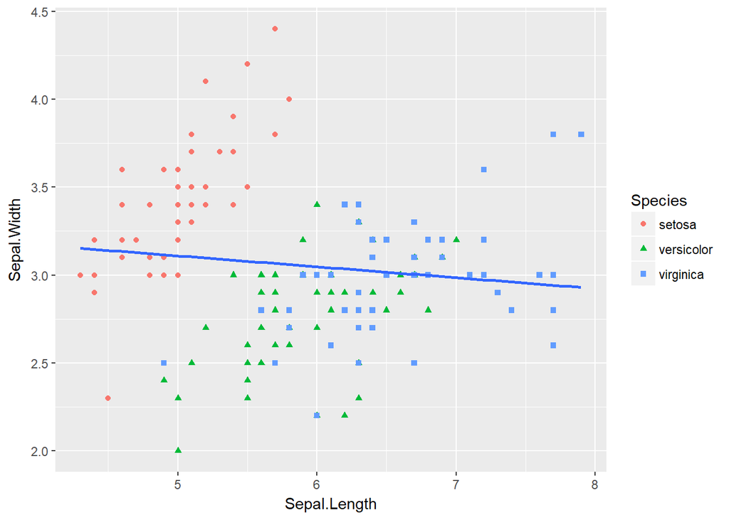

```r
iris %>%
  ggplot2::ggplot(ggplot2::aes(x = Sepal.Length, y = Sepal.Width)) +
    ggplot2::geom_point(ggplot2::aes(colour = Species, shape = Species)) +
    ggplot2::geom_smooth(method = "lm", se = FALSE)
```

## 散布図と層別の回帰線

`car::scatterplot`関数は層別の回帰線も描けます。`groups`オプションが指定されていると自動的に層別の回帰線を描きますが明示的に指定したい場合は`by.groups`オプションを`TRUE`に指定してください。

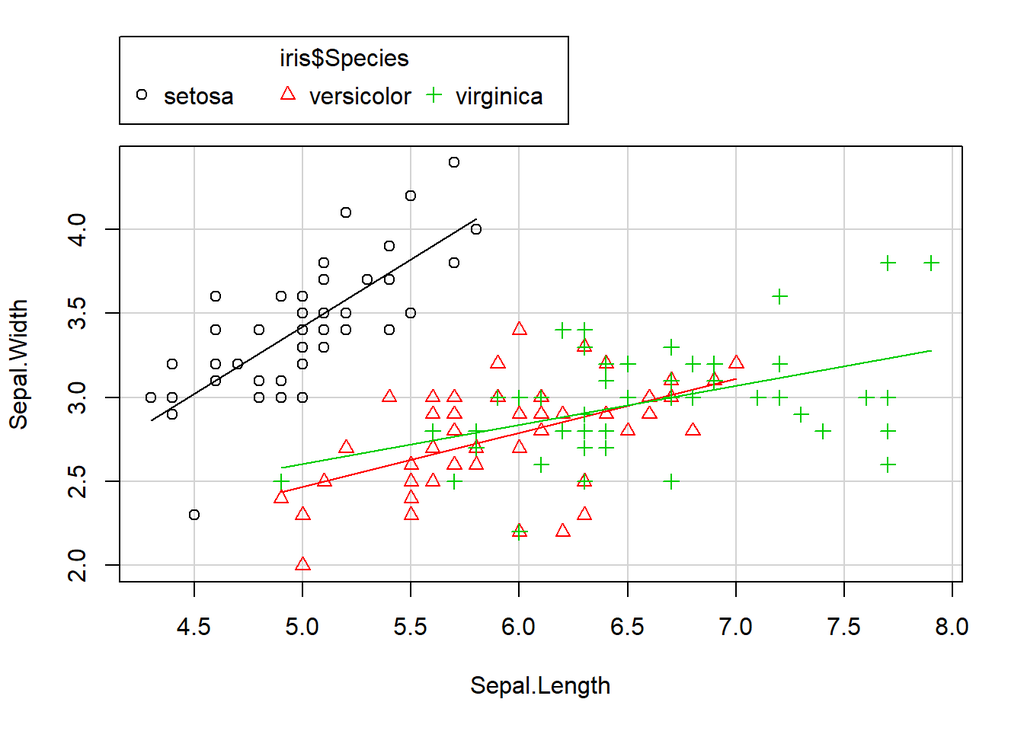

```r
car::scatterplot(Sepal.Width ~ Sepal.Length, data = iris, by.groups = TRUE,
                 groups = iris$Species, smooth = FALSE, spread = FALSE)
```

`ggplot2`パッケージで層別の回帰線を描には`ggplot2::aes`関数の指定位置を変更するのが簡単です。

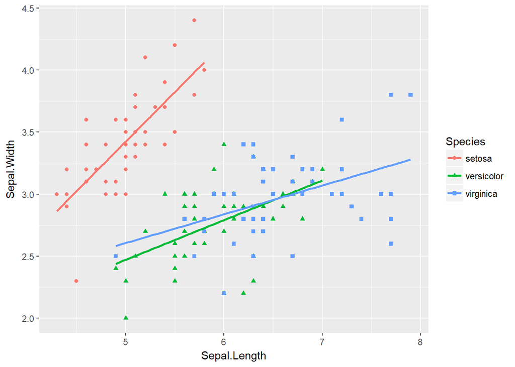

```r
iris %>%
  ggplot2::ggplot(ggplot2::aes(x = Sepal.Length, y = Sepal.Width,
                               colour = Species, shape = Species)) +
    ggplot2::geom_point() +
    ggplot2::geom_smooth(method = "lm", se = FALSE)
```

# ラベルを表示する

散布図はデータの数が多いことが多くどのデータか識別するためにテキストラベル（以降、ラベルと表記）を表示したいことがあります。ラベル表示は追加パッケージを用いると比較的簡単にできます。

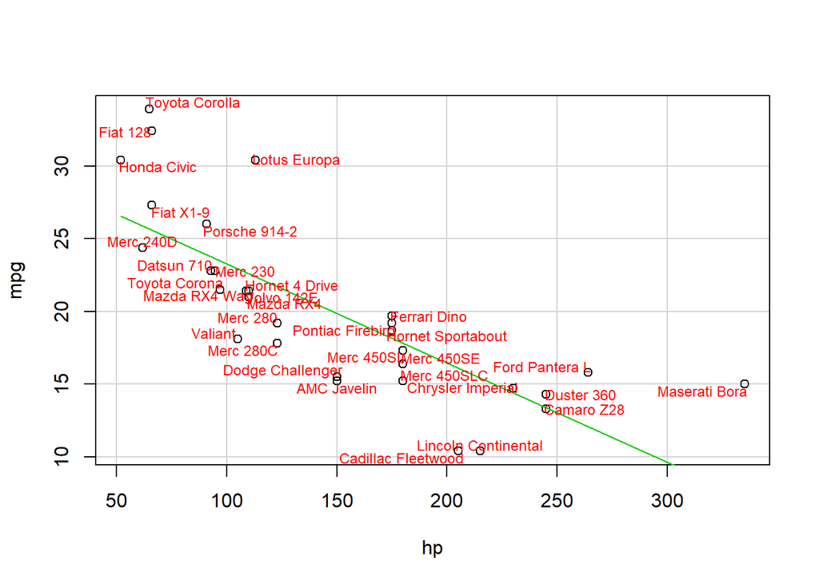

```r
car::scatterplot(mpg ~ hp, data = mtcars, reg.line = lm, smooth = FALSE,
                 span = 0.5, spread = FALSE, boxplots = FALSE)
with(mtcars, maptools::pointLabel(x = hp, y = mpg,
                                  labels = row.names.data.frame(mtcars),
                                  col = "red", cex = 0.75))
```

`ggplot2`パッケージでは`ggplot2::geom_text`関数または`ggplot2::geom_label`関数を用います。

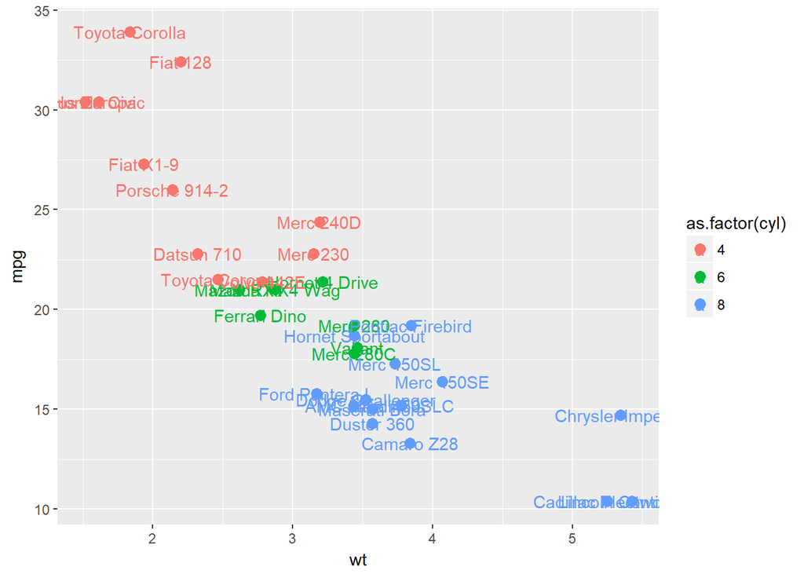

```r
mtcars %>%
  ggplot2::ggplot(ggplot2::aes(x = wt, y = mpg, colour = as.factor(cyl))) +
    ggplot2::geom_point(size = 3) +
    ggplot2::geom_text(ggplot2::aes(label = rownames(.)))
```

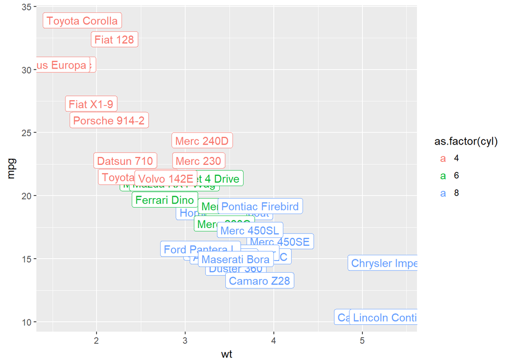

```r
mtcars %>%
  ggplot2::ggplot(ggplot2::aes(x = wt, y = mpg, colour = as.factor(cyl))) +
    ggplot2::geom_point(size = 3) +
    ggplot2::geom_label(ggplot2::aes(label = rownames(.)))
```

データ数が多いとどうしてもラベルが重なってしまいます。ラベルが重なってしまうのを避ける方法はラベルが重ならないように描画するを参照してください。

[CC BY-NC-SA 4.0](http://creativecommons.org/licenses/by-nc-sa/4.0/deed.ja) , Sampo Suzuki [2018-04-20 18:44(JST)]